# Partially conditional survival models for liver related outcomes using HALT-C trial data

Marshall Brown and Yingye Zheng  
16 October 2014

### Data

HALT-C Trial Data:

We **fit** the model on non-treatment arm:

- 533 individuals (134 observed outcomes)

We **evaluate** the model performance on the treatment arm:

- 515 individuals (108 observed outcomes)

### Outcomes of interest

We combine the following outcomes, using the first observed event time:

1. Liver related death
2. Hepatic Decompensation:
   - variceal bleed
   - ascites
   - bacterial perionitis
   - hepatic encephalopathy
3. HCC or presumed HCC
4. Liver transplant

### Outcomes (non-censored observations)

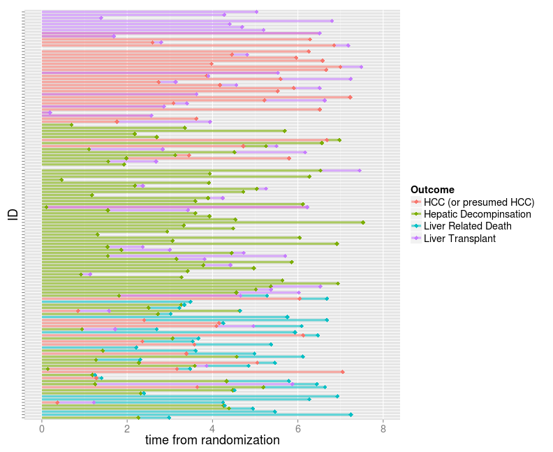

### Predictive markers of interest

**bold** markers used in partly conditional models, * indicates markers used in previous models:

- **Albumin** *
- Aspertate aminotransferase (AST)
- Alkaline phosphatase (ALT)
- AST/ALT ratio *
- Total bilirubin *
- **Platelet count** *
- **APRI**
- duration - Estimated duration of HCV infection since enrollment

### Predictive markers of interest

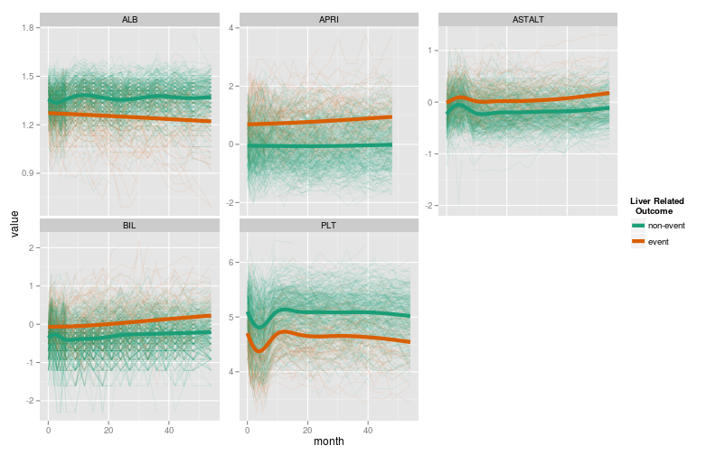

### Previous models (Ghany et. al)

Cox model using ALB, ASTALT, BIL, PLT baseline values and change in month 24 values to predict outcomes 2-4 (no death)

I replicated this model using our outcome, and extended it slightly:

1. 'Discrete model' discretize marker values based on percent change
2. 'Continous model' use continuous percent change as variable

### PC Models (step 1 of 2)

For individual \( i \) and marker measurement \( j \) we smooth over marker values by modelling marker value \( Y \) with a mixed effects model:  
\[ Y_{ij} = \beta_0 + \beta_1 *t + b_{0i} + b_{1i} *t + \epsilon \]

We wish to include the fitted \( \widehat{Y_{ij}} \) into a proportional hazards model to predict risk. However, \( \widehat{Y_{ij}} \) uses information across all measurement times, which we will not have when making predictions for new individuals. Thus, for a given time of prediction \( s_j \), we obtain the best linear unbiased predictor (blup) of \( \widehat{Y_{ij}} \) using measurement data only up to time \( s_j \).

### PC Models (step 2 of 2)

**Model 1** Use smoothed marker in a Cox model where \( \tau \) is the measurement time, and \( f \) is the natural cubic spline with two knots. Outcome time \( t \) is outcome time from measurement.

\[ \begin{aligned} \lambda(t|X) = \lambda_0(t|X)exp(f_1(\tau_i) &+ \beta_1 \widehat{PLT^{blup}_i} \\ & + \beta_2 \widehat{ALB^{blup}_i} \\ & + \beta_3 \widehat{APRI^{blup}_i} ) \end{aligned} \]

**Model 2** Include random slope from the mixed effects models in the model as well.

### PC Models

**PC1**

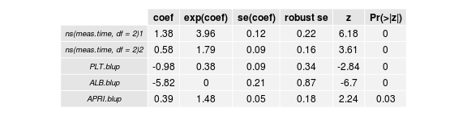

**PC 2**

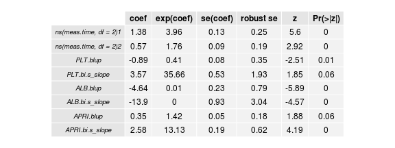

### Dynamic Predictions

- This allows us to make a prediction at any measurement time \( \tau \), not just at month 24 as with the previous models.

### Dynamic Predictions (subj 9)

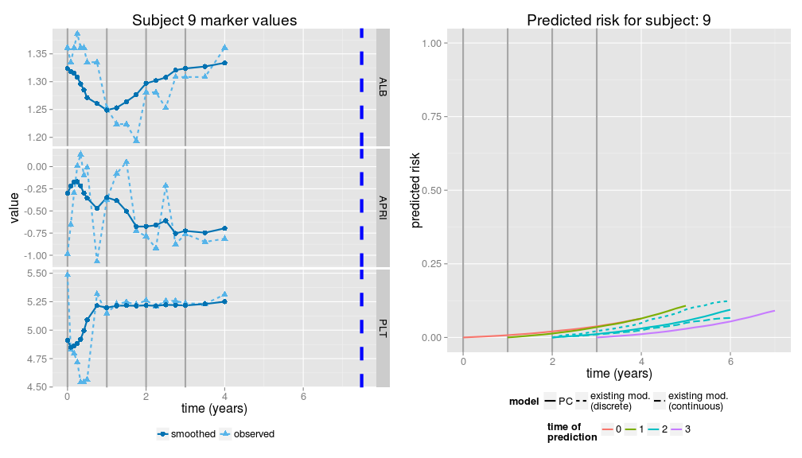

### Dynamic Predictions (subj 9)

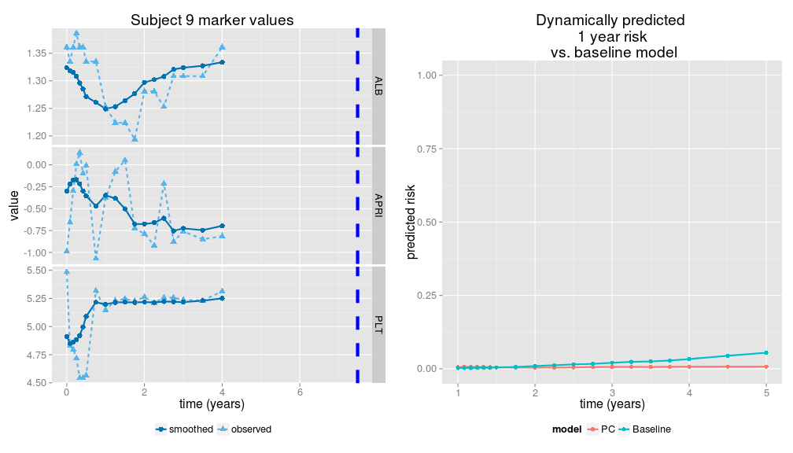

### Dynamic Predictions (subj 494)

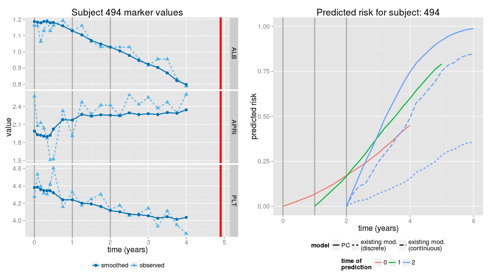

### Dynamic Predictions (subj 494)

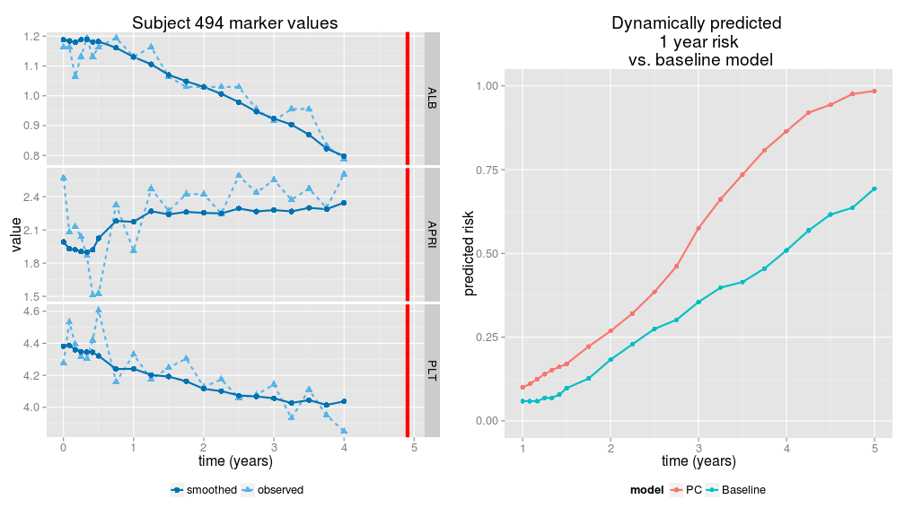

### Dynamic Predictions (subj 1712)

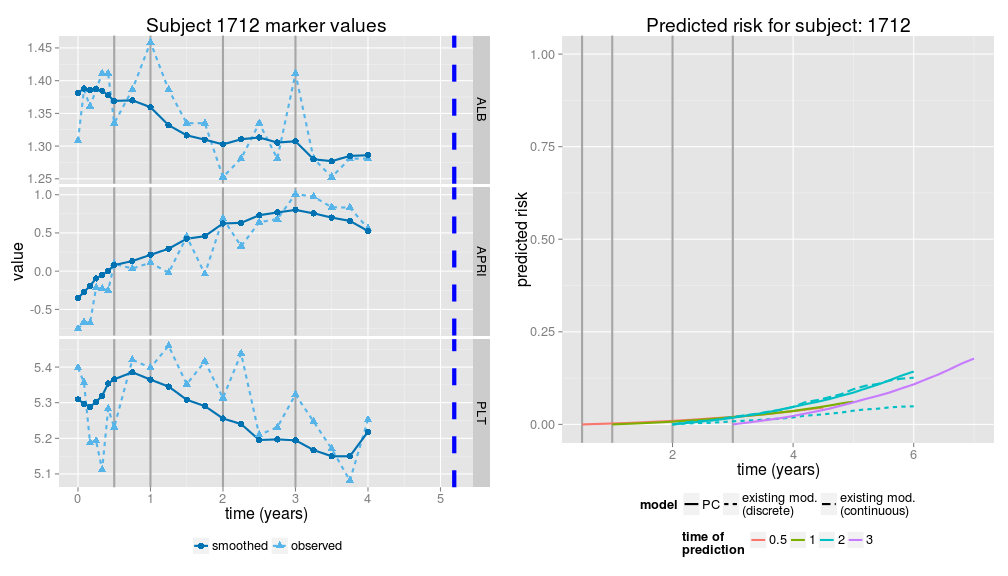

### Dynamic Predictions (subj 1712)

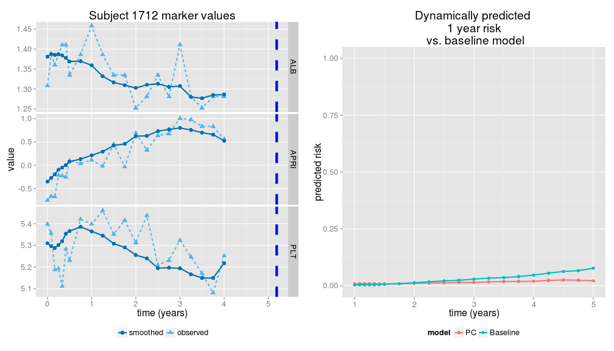

### Dynamic Predictions (subj 2066)

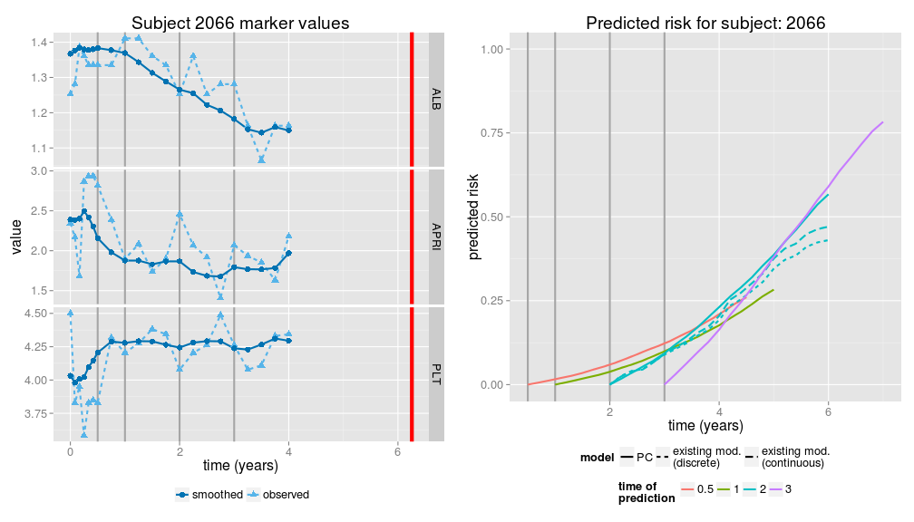

### Dynamic Predictions (subj 2066)

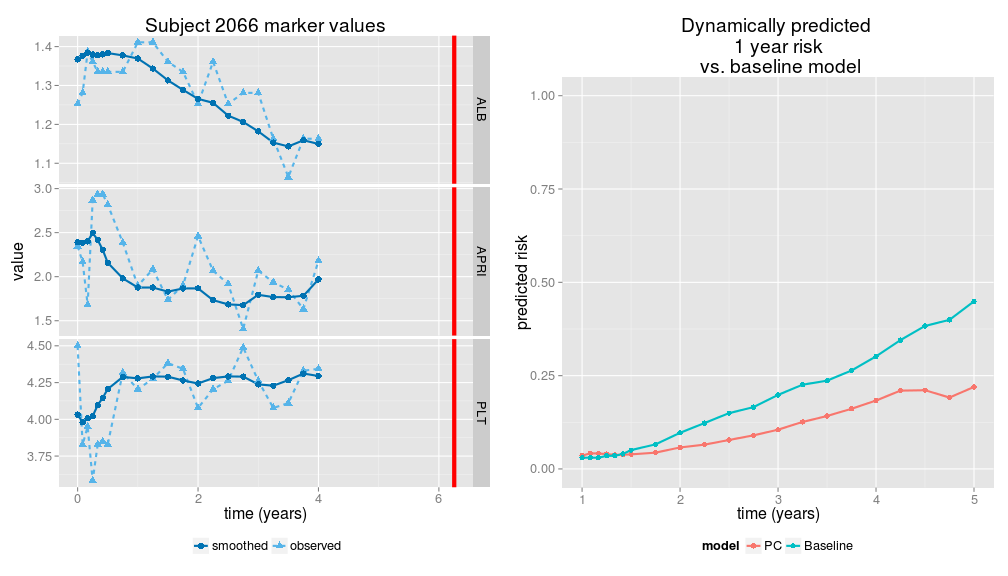

### Dynamic Predictions (subj 2021)

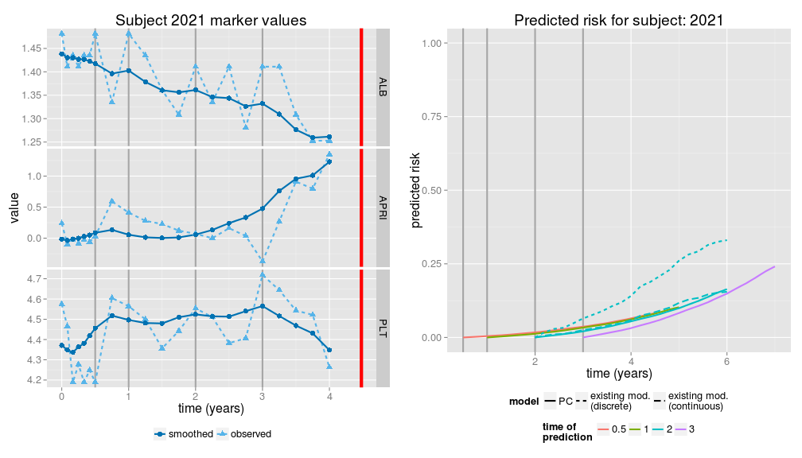

### Dynamic Predictions (subj 2021)

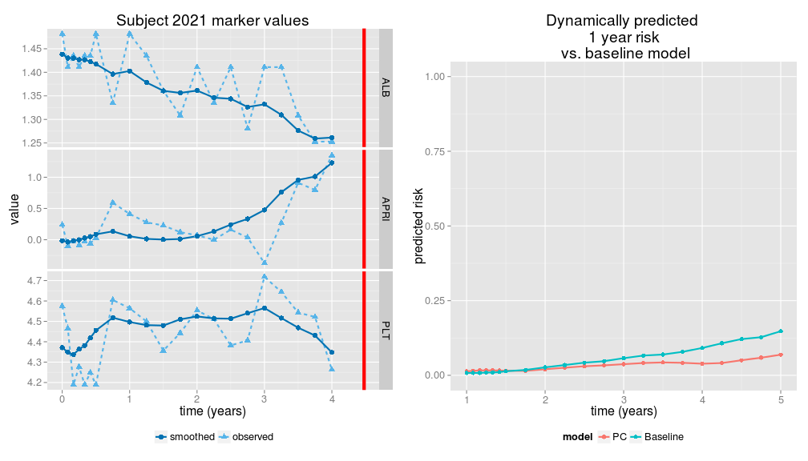

### Model Evaluation

Measures of accuracy for predictions made at year 2 for 1 year event outcome.

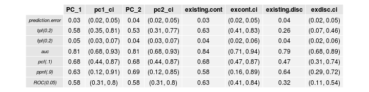

### Model Evaluation

Prediction Error is reduced by PC models

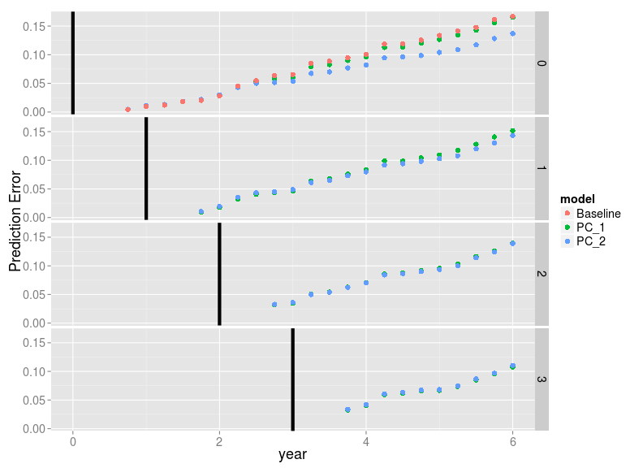

### Model Evaluation

AUC remains about the same

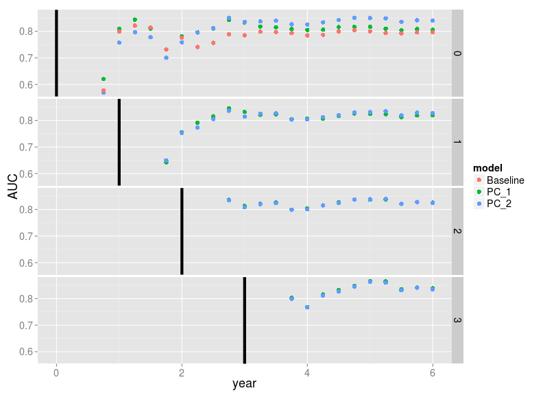

### Future Steps

- Primary 'prediction' time 1 year in the future…maybe taylor partly conditional logistic model to focus on this aim.
- We are primarily predicting HCC or Hepatic Decompinsation (because they often happen before liver transplant or death), we could build models to predict these outcomes separately.